# Social Network Analysis

Homework 1

Emma Pérez Hernández - 100392586

2023-04-21

```r
library(readr)
library(igraph)
library(ggplot2)
set.seed(123)
```

## 0. Network description and data load

*LastFM Asia Social Network*

The chosen network is a social network of LastFM Asian users available at the [Stanford Network Analysis Platform (SNAP)](https://snap.stanford.edu/index.html). Last.fm is a social media, an internet radio, and also a music recommendation system that builds profiles and statistics about musical preferences, based on data sent by registered users.

According to SNAP, the data was collected from the public API in March 2020. Nodes are LastFM users from Asian countries and edges are mutual follower relationships between them. The vertex features are extracted based on the artists liked by the users. It can be downloaded in csv format from [LastFM Asia Social Network](https://snap.stanford.edu/data/feather-lastfm-social.html).

The network will be analyzed in terms of centrality, clustering coefficient and community structure.

To start with, the data is loaded to R.

```r
# Read the graph file into a data frame
df<- read_delim("C:/Users/emmaa/OneDrive/Escritorio/Semester II/Social Network Analysis/HW1/lastfm_asia/lasftm_asia/lastfm_asia_edges.csv", delim = ",")
```

Now, the data is converted into a graph object. Since edges are following relationships which are mutual between users, the network is undirected.

```r
# Convert the data frame to an igraph object
g <- graph.data.frame(df, directed = FALSE)

g
```

```
## IGRAPH 9d6e019 UN-- 7624 27806 --
## + attr: name (v/c)
## + edges from 9d6e019 (vertex names):
##  [1] 0--747  1--4257 1--2194 1--580  1--6478 1--1222 1--5735 1--7146 1--2204
## [10] 1--126  1--2639 2--562  2--1492 2--6    2--5303 2--7128 2--4154 2--5179
## [19] 3--1728 3--4560 3--5060 3--1351 3--6503 3--7089 3--4319 3--6095 3--272
## [28] 3--4433 3--2900 3--3381 3--5943 3--2107 3--6940 3--2013 3--6046 3--5823
## [37] 4--5770 5--5454 6--5856 6--667  6--6180 6--598  6--870  6--3079 6--1834
## [46] 6--6283 6--7340 6--7279 6--342  6--1492 6--4405 6--1462 6--7128 6--1284
## [55] 6--1551 6--3291 6--167  7--177  7--6243 7--7589 7--2854 7--6931 7--6250
## [64] 7--428  7--2142 8--1686 9--4481 9--1795 9--2660 9--6053 9--246  9--3843
## + ... omitted several edges
```

Above we can see a general description of the graph. To visualize it, I save it in a convenient format to load it into Gephi.

```r
#plot(g)
#save graph for gephi
write.graph(g,file="./g.graphml",format="graphml")
```

Plotting the network in Gephi, using the ForceAtlas2 algorithm:

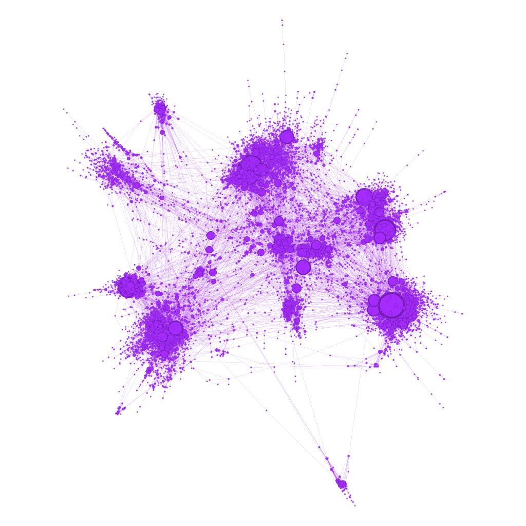

## 1. Nodes and links

*What is the number of nodes and links?*

To see the number of nodes and links, we use `vcount`to count the vertex and `ecount`to count the edges.

```r
vcount(g)
```

```
## [1] 7624
```

```r
ecount(g)
```

```
## [1] 27806
```

There are 7624 nodes, this is, Asian users, and 27806 links, which are the mutual follower relationships.

We can check fi the network is connected or not to continue with the analysis.

```r
gd <- decompose(g)
gd
```

```
## [[1]]
## IGRAPH 9d97d51 UN-- 7624 27806 --
## + attr: name (v/c)
## + edges from 9d97d51 (vertex names):
##  [1] 0--747  1--4257 1--2194 1--580  1--6478 1--1222 1--5735 1--7146 1--2204
## [10] 1--126  1--2639 2--562  2--1492 2--6    2--5303 2--7128 2--4154 2--5179
## [19] 3--1728 3--4560 3--5060 3--1351 3--6503 3--7089 3--4319 3--6095 3--272
## [28] 3--4433 3--2900 3--3381 3--5943 3--2107 3--6940 3--2013 3--6046 3--5823
## [37] 4--5770 5--5454 6--5856 6--667  6--6180 6--598  6--870  6--3079 6--1834
## [46] 6--6283 6--7340 6--7279 6--342  6--1492 6--4405 6--1462 6--7128 6--1284
## [55] 6--1551 6--3291 6--167  7--177  7--6243 7--7589 7--2854 7--6931 7--6250
## [64] 7--428  7--2142 8--1686 9--4481 9--1795 9--2660 9--6053 9--246  9--3843
## + ... omitted several edges
```

There are no disconnected components, since we only get 1 element in the decomposition which contain all the nodes.

## 2. Degree

*What is the average degree in the network?*

```r
# Calculate the degree of each vertex
deg <- degree(g)

# Calculate the average degree
avg_deg <- mean(deg)
avg_deg
```

```
## [1] 7.294334
```

The average degree is 7.3, so each user has on average 7 connections (mutual follow), which is not very high to be an online social network. Networks with a low average degree tend to be more fragmented (less connected) that those with high ones.

*And the standard deviation of the degree?*

```r
# Degree standard deviation
sd_deg <- sd(deg)
sd_deg
```

```
## [1] 11.49987
```

The standard deviation of the degree in a network measures the variation in the degree distribution of the network. It indicates how much the degrees of the nodes in the network deviate from the average degree. In this case, the standard deviation is equal to 11.5.

## 3. Degree distribution

*Plot the degree distribution in linear-linear scale and in log-log-scale.*

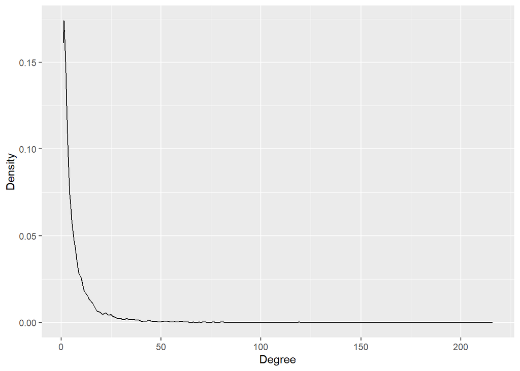

```r
ggplot() + geom_density(aes(x=degree(g))) + labs(x="Degree",y="Density")
```

From the degree distribution of the network, we can clearly see a power-law distribution shape, with a very large tail (few users highly connected) and a big density close to 0 (many users with few following relationships).

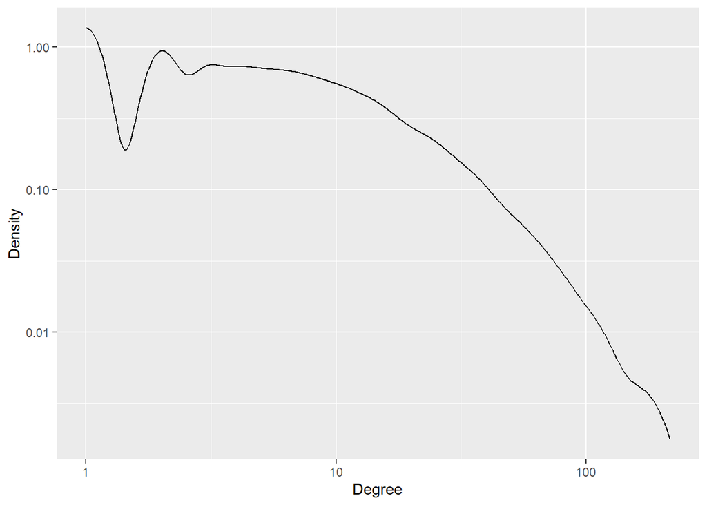

```r
ggplot() + geom_density(aes(x=degree(g))) + labs(x="Degree",y="Density") + scale_x_log10() + scale_y_log10()
```

*What is the degree of the most connected node?*

```r
max(deg)
```

```
## [1] 216
```

The most connected node has 216 links, which means that follows and it is followed by 216 people.

## 4. Transitivity (clustering)

*What is the clustering coefficient (transitivity) in the network?*

The clustering coefficient of a node in a network is the ratio of the number of connections between the node’s neighbors to the maximum number of connections that could exist between them. It measures the proportion of the possible connections between a node’s neighbors that actually exist, so it is an important measure of the local structure of the network.

The overall clustering coefficient of a network is the average of the clustering coefficients of all nodes.

```r
transitivity(g)
```

```
## [1] 0.1786225
```

In this case, the transitivity is 0.17, which means that only 17% of possible connections between the neighbors of a given node actually exist. Thus, the clustering coefficient is relatively low, and nodes in the network are sparsely connected to one another.

## 5. Assortativity

*What is the assortativity (degree) in the network?*

The assortativity degree is a measure of the tendency of nodes in a network to connect to other nodes with similar degrees, which is normally positive in social networks. It is an important measure of the structural properties of the network.

```r
assortativity_degree(g)
```

```
## [1] 0.01707317
```

In the LastFM network, the assortativity coefficient is 0.017. Therefore, the assortativity degree is positive but close to 0: nodes are a bit more likely to be connected to nodes of similar degree. A value of 0 would indicate a neutral correlation between degrees, where nodes are equally likely to be connected to nodes of any degree.

## 6. Communities

*Using the Louvain method, does the network have a community structure?* *If so, what is its modularity?*

Since the network is undirected, we can use the Louvain algorithm.

```r
louvain <- cluster_louvain(g, weights = NULL)
sizes(louvain)
```

```
## Community sizes
##    1    2    3    4    5    6    7    8    9   10   11   12   13   14   15   16
##  528  924  608  955  499 1031  298 1048  567  109   72  149  152  215   62   60
##   17   18   19   20   21   22   23   24   25   26
##  167   46   85   12    4    5   11    7    6    4
```

Communities are partitions of the network, this is, divisions into a number of group such that each node belongs only to one group. To find the best partition, we use modularity as objective function. The higher the modularity, the better the partition.

```r
modularity(louvain)
```

```
## [1] 0.8122669
```

The modularity is very high, equal to 0.81, so the communities partition is good.

To see the communities I will plot them in Gephi, since they cannot be properly seen in R due to the network dimension:

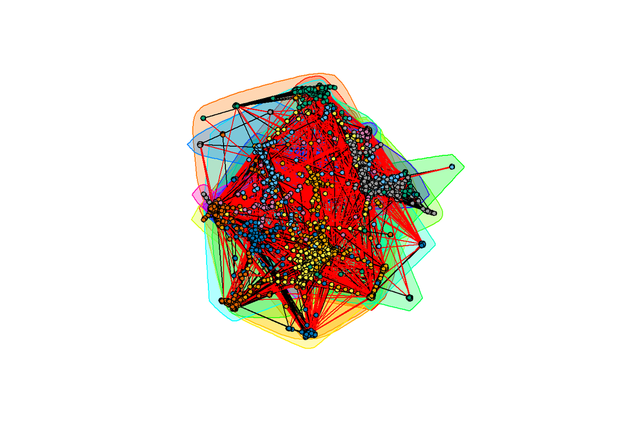

```r
plot(louvain,g, vertex.size=4, vertex.label = "")
```

Network community structure in Gephi:

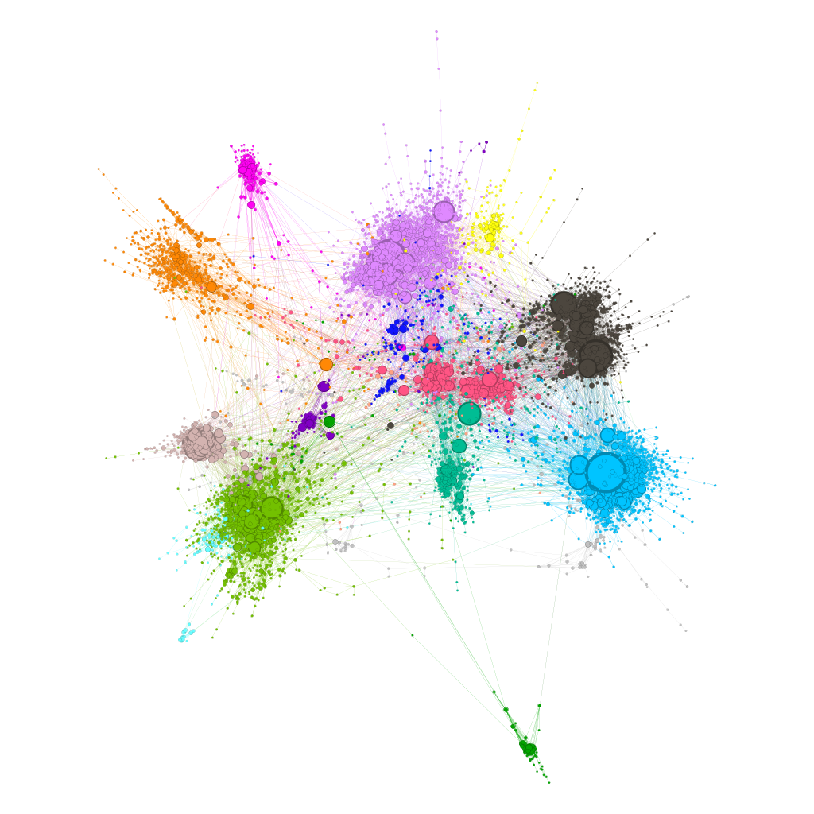

Gephi identifies 22 communities with 0.81 modularity by using the same Louvain algorithm [2], from its report we get:

- Modularity: 0.811
- Modularity with resolution: 0.811
- Number of Communities: 22

Since the network refers to users in the Asian countries, maybe these communities refer to people from same country, or people who like the same artist or music style.

## 7. Clustering coefficient

*Test that the clustering coefficient in the network cannot be statistically explain by a configuration model in which the nodes have the same degree as the original*

As it has been shown above, the network is very heterogeneous in degree: some LastFM users are much more connected than others. We can compare the transitivity in the real network (0.17) with the one from a configuration model realization with the same degree distribution LastFM network (which is used as the null model).

```r
#Transitivity of LastFM network
transitivity(g)
```

```
## [1] 0.1786225
```

```r
#Transitivity of configuration model with the same degrees as in the LastFM network
transitivity(sample_degseq(degree(g)))
```

```
## [1] 0.009526926
```

They are very different, since in the degree-sequence generated network the transitivity is almost 0.

To check if this difference is statistically significant, we need to generate the distribution of clustering values from the degree-sequence model with the same degree sequence as the LastFM network.

```r
# Degree-sequence model transitivity for 1000 realizations
trans_model <- replicate(1000,transitivity(sample_degseq(degree(g))))
```

We plot the generated model along with the vertical line that indicates the transitivity of the LastFM network (0.17). Now, we compare the actual value from the real network with the distribution of transitivity values from the degree-sequence model.

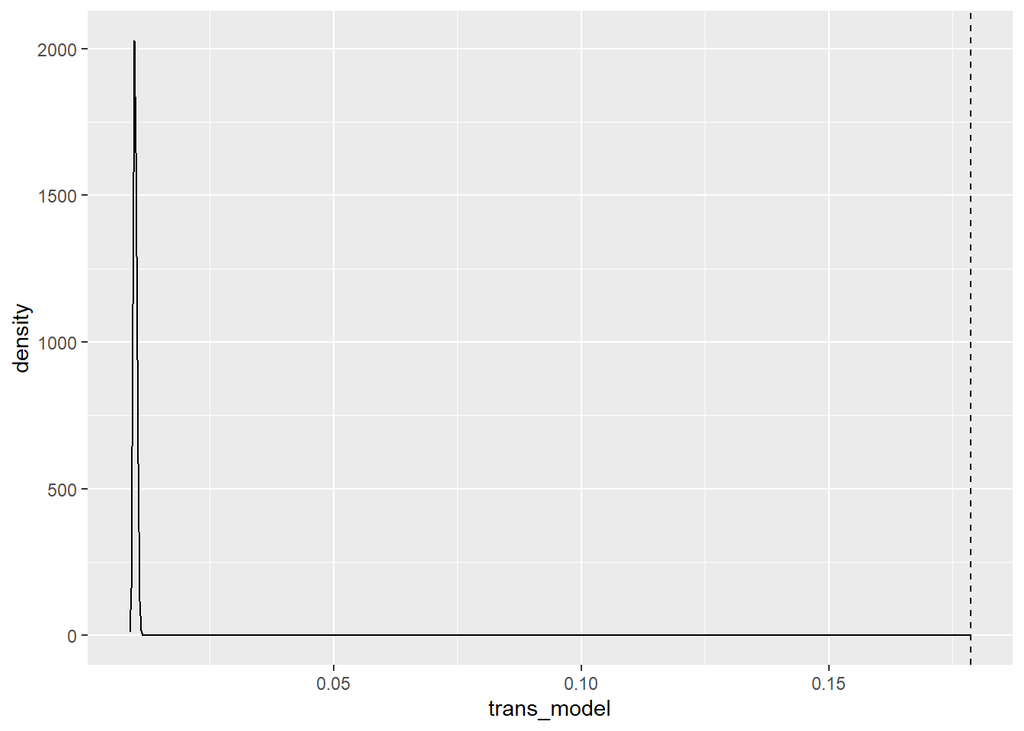

```r
ggplot() + geom_density(aes(x=trans_model)) +
  geom_vline(xintercept = transitivity(g),linetype=2)
```

Assuming the distribution for the degree-sequence is Gaussian, then the p-value of our hypothesis is:

```r
dnorm(transitivity(g),mean=mean(trans_model),sd=sd(trans_model))
```

```
## [1] 0
```

Since the p-value is 0, we reject the null hypothesis and therefore the transitivity is not just a consequence of the heterogeneity in the degrees.

## 8. Centrality (closeness)

*Visualize the neighborhood of the node with the largest centrality (closeness)*

Closeness is a global, distance centrality measure in which the most central node is that which is closest to the other nodes. It is calculated as the inverse of the sum of distances from one node to all other nodes.

```r
# Compute closeness
cl <- closeness(g)

# Sort nodes by closeness
cl %>% sort(decreasing = T) %>% head()
```

```
##         7199         7237         4356         2854         5454         5127
## 3.813592e-05 3.747564e-05 3.694126e-05 3.677687e-05 3.670802e-05 3.602825e-05
```

The node with the largest closeness value is the 7199. We can plot its ego network:

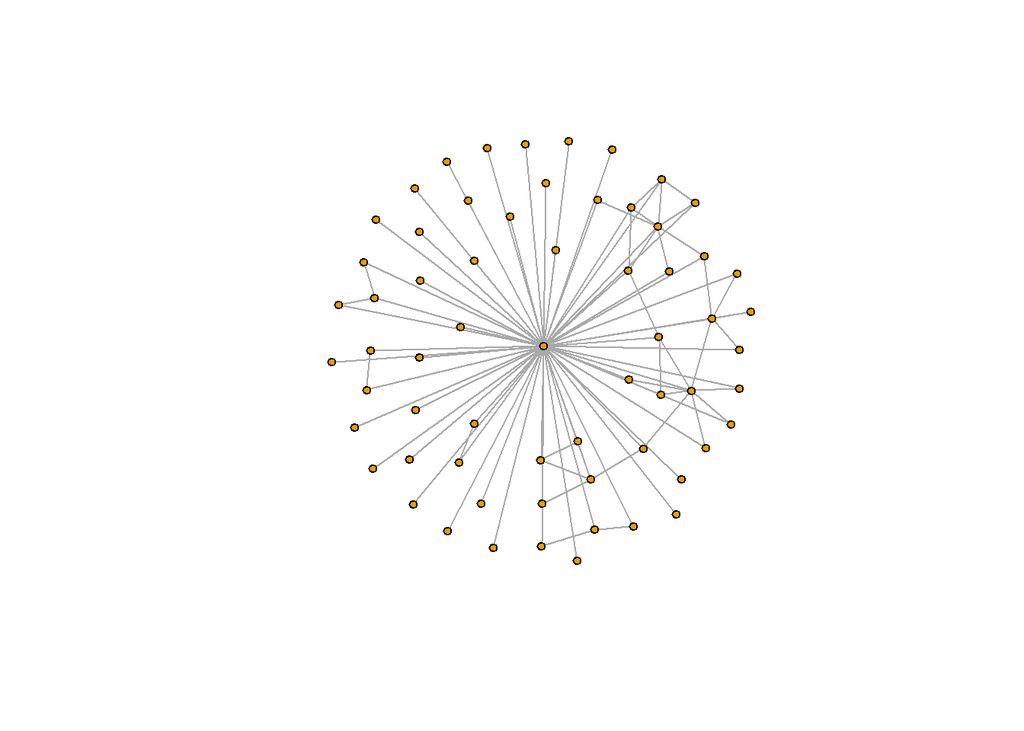

```r
ego7199 <- make_ego_graph(g,order = 1,"7199")[[1]]
plot(ego7199, vertex.size=4, vertex.label = "")
```

### References

[1] B. Rozemberczki and R. Sarkar. Characteristic Functions on Graphs: Birds of a Feather, from Statistical Descriptors to Parametric Models. 2020.

[2] Vincent D Blondel, Jean-Loup Guillaume, Renaud Lambiotte, Etienne Lefebvre, Fast unfolding of communities in large networks, in Journal of Statistical Mechanics: Theory and Experiment 2008 (10), P1000

[*] ChatGPT, OpenAI. Used for guidance on how to use Gephi.